# TUGAS MINGGU 67 MPDW

Fajryanti Kusuma Wardani

2023-10-16

# Pemanggilan Packages

```r
library(ggplot2)
library(tsibble)
library(tseries)
library(MASS)
library(forecast)
library(TSA)
library(TTR)
library(aTSA)
library(graphics)
library(readxl)
```

## Impor Data

```r
library("rio")
data67 <- import("https://raw.githubusercontent.com/fajryanti/mpdw-p1/main/PRAKTIKUM%20MINGGU%201/suhu%20udara%20di%20medan.csv")
```

### Ubah ke data Time Series

```r
data67.ts <- ts(data67$T2M)
```

### Plot Time Series

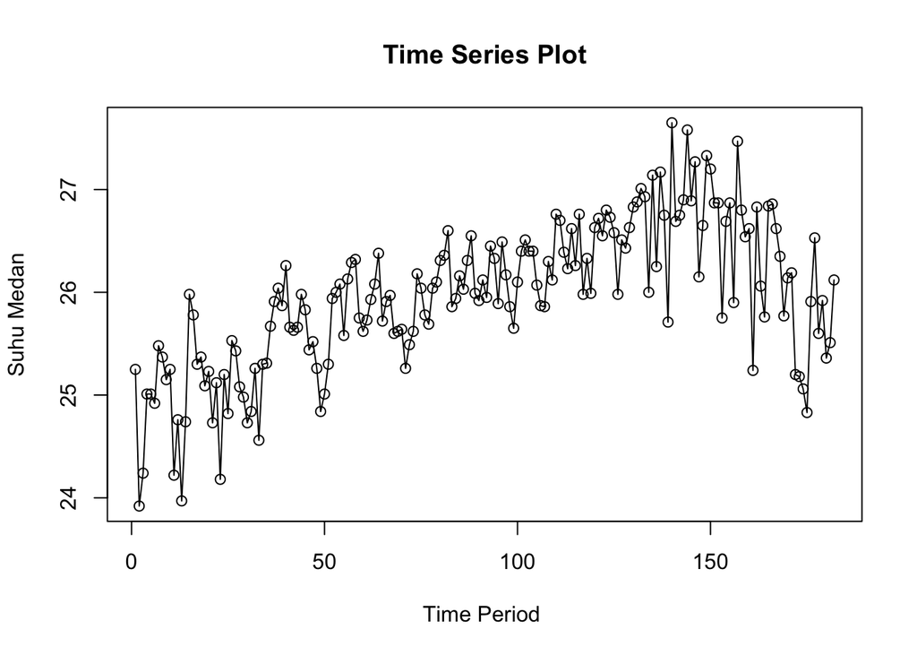

```r
ts.plot(data67.ts, xlab="Time Period ", ylab="Suhu Medan",
        main = "Time Series Plot")
points(data67.ts)
```

Plot deret waktu di atas menunjukkan bahwa data tidak stasioner dalam rataan, ditandai dengan data yang tidak menyebar di sekitar nilai tengahnya. Berdasarkan pola data, pembagian data latih dan data uji ditetapkan dengan proporsi 79%:21%.

### Plot Data Latih

```r
data.train <- data67.ts[1:143]
head(data.train)
```

```
## [1] 25.25 23.92 24.24 25.01 25.01 24.92
```

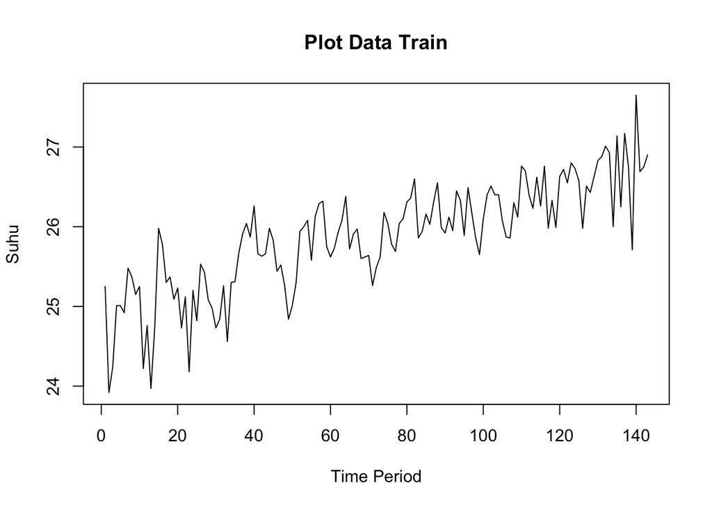

```r
plot.ts(data.train, lty=1, xlab="Time Period", ylab="Suhu", main="Plot Data Train")
```

Berdasarkan plot data train deret waktu di atas menunjukkan bahwa data tidak stasioner dalam rataan, ditandai dengan data yang tidak menyebar di sekitar nilai tengahnya.

### Plot Data Uji

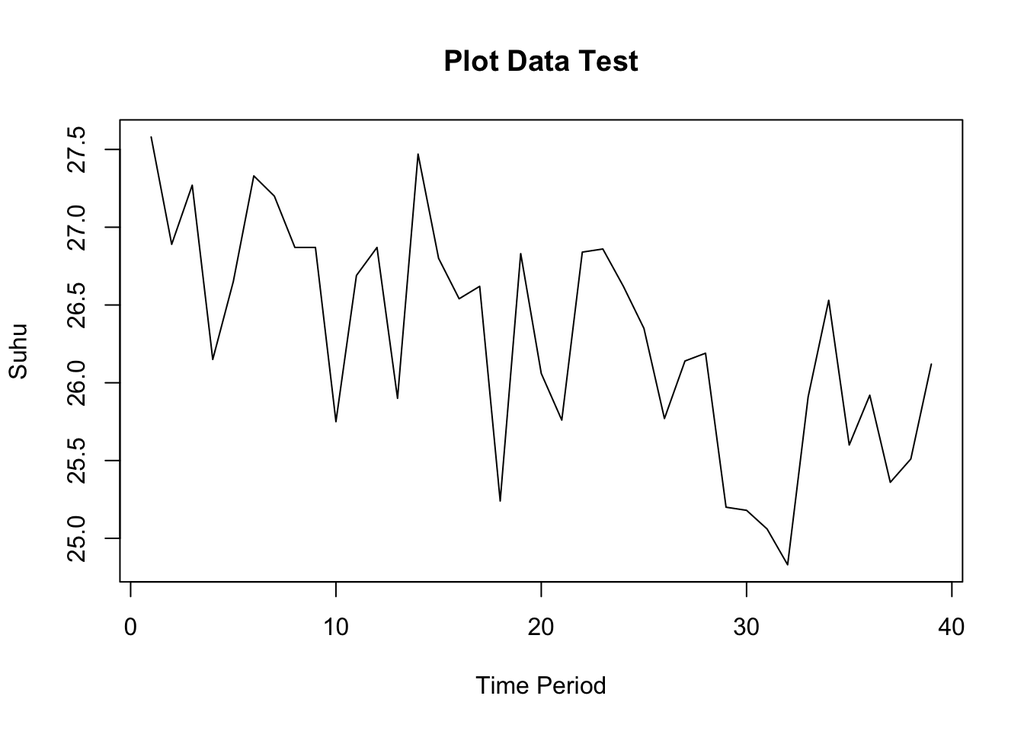

```r
data.test <- data67.ts[144:182]
plot.ts(data.test, lty=1, xlab="Time Period", ylab="Suhu", main="Plot Data Test")
```

Berdasarkan plot data test deret waktu di atas menunjukkan bahwa data tidak stasioner dalam rataan, ditandai dengan data yang tidak menyebar di sekitar nilai tengahnya.

## Uji Stasioneritas Data

### Plot ACF

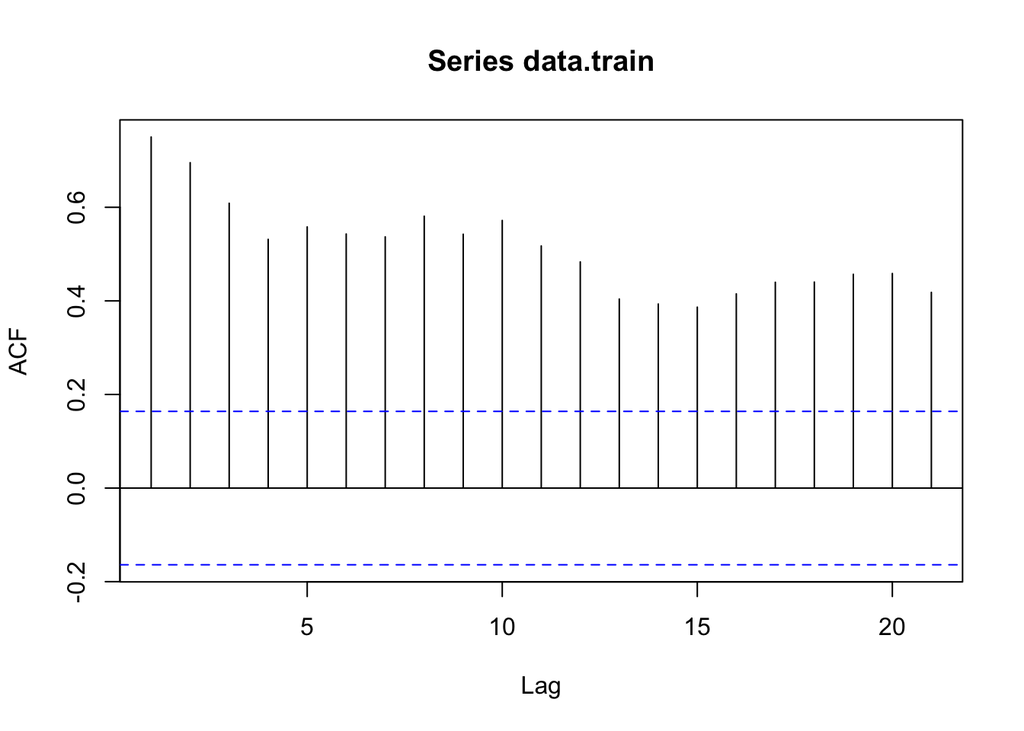

```r
acf(data.train)
```

Berdasarkan plot ACF, terlihat bahwa plot ACF data menurun secara perlahan *tails of slowly*. Hal ini juga menjadi indikasi bahwa data tidak stasioner dalam rataan.

### Uji ADF

```r
tseries::adf.test(data.train, k=20)
```

```
##
##  Augmented Dickey-Fuller Test
##
## data:  data.train
## Dickey-Fuller = -1.9695, Lag order = 20, p-value = 0.5891
## alternative hypothesis: stationary
```

$H_0$ : Data tidak stasioner dalam rataan

$H_1$ : Data stasioner dalam rataan

### Plot Box-Cox

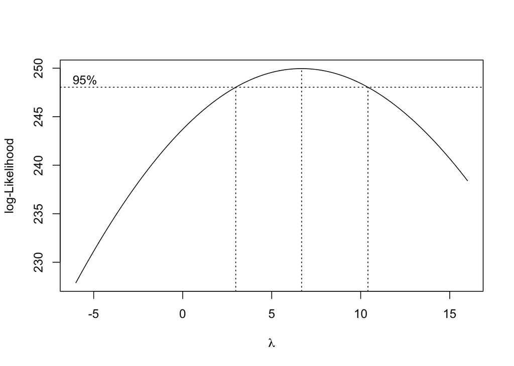

```r
index <- seq(1:143)
bc = boxcox(data.train~index, lambda = seq(-6,16,by=0.01))
```

```r
#Nilai Rounded Lambda
lambda <- bc$x[which.max(bc$y)]
lambda
```

```
## [1] 6.68
```

```r
#SK
bc$x[bc$y > max(bc$y) - 1/2 * qchisq(.95,1)]
```

```
##   [1]  2.99  3.00  3.01  3.02  3.03  3.04  3.05  3.06  3.07  3.08  3.09  3.10
##  [13]  3.11  3.12  3.13  3.14  3.15  3.16  3.17  3.18  3.19  3.20  3.21  3.22
##  [25]  3.23  3.24  3.25  3.26  3.27  3.28  3.29  3.30  3.31  3.32  3.33  3.34
##  [37]  3.35  3.36  3.37  3.38  3.39  3.40  3.41  3.42  3.43  3.44  3.45  3.46
##  [49]  3.47  3.48  3.49  3.50  3.51  3.52  3.53  3.54  3.55  3.56  3.57  3.58
##  [61]  3.59  3.60  3.61  3.62  3.63  3.64  3.65  3.66  3.67  3.68  3.69  3.70
##  [73]  3.71  3.72  3.73  3.74  3.75  3.76  3.77  3.78  3.79  3.80  3.81  3.82
##  [85]  3.83  3.84  3.85  3.86  3.87  3.88  3.89  3.90  3.91  3.92  3.93  3.94
##  [97]  3.95  3.96  3.97  3.98  3.99  4.00  4.01  4.02  4.03  4.04  4.05  4.06
## [109]  4.07  4.08  4.09  4.10  4.11  4.12  4.13  4.14  4.15  4.16  4.17  4.18
## [121]  4.19  4.20  4.21  4.22  4.23  4.24  4.25  4.26  4.27  4.28  4.29  4.30
## [133]  4.31  4.32  4.33  4.34  4.35  4.36  4.37  4.38  4.39  4.40  4.41  4.42
## [145]  4.43  4.44  4.45  4.46  4.47  4.48  4.49  4.50  4.51  4.52  4.53  4.54
## [157]  4.55  4.56  4.57  4.58  4.59  4.60  4.61  4.62  4.63  4.64  4.65  4.66
## [169]  4.67  4.68  4.69  4.70  4.71  4.72  4.73  4.74  4.75  4.76  4.77  4.78
```

[output cut: 47 more lines]

Gambar di atas menunjukkan nilai *rounded value* ($\lambda$) optimum sebesar **6.68** dan pada selang kepercayaan 95% nilai memiliki batas bawah **2.99** dan batas atas **10.40**. Selang tersebut tidak memuat nilai satu sehingga dapat dikatakan bahwa data bangkitan tidak stasioner dalam ragam.

Kesimpulan : Tidak Stasioner dalam Ragam, Tidak Stasioner dalam Rataan

## Penanganan Ketidakstasioneran Data

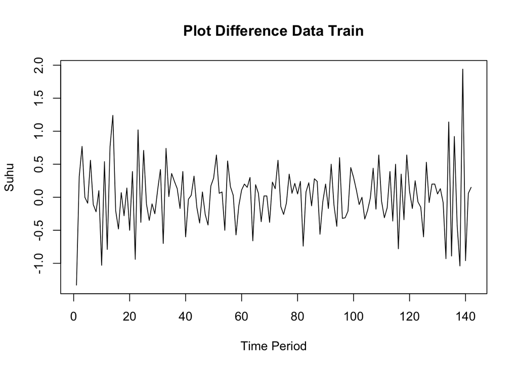

```r
train.diff <- diff(data.train,differences = 1)
plot.ts(train.diff, lty=1, xlab="Time Period", ylab="Suhu", main="Plot Difference Data Train")
```

Berdasarkan plot data deret waktu, terlihat bahwa data sudah stasioner dalam rataan ditandai dengan data bergerak pada nilai tengah tertentu (tidak terdapat trend ataupun musiman pada data).

### Plot ACF

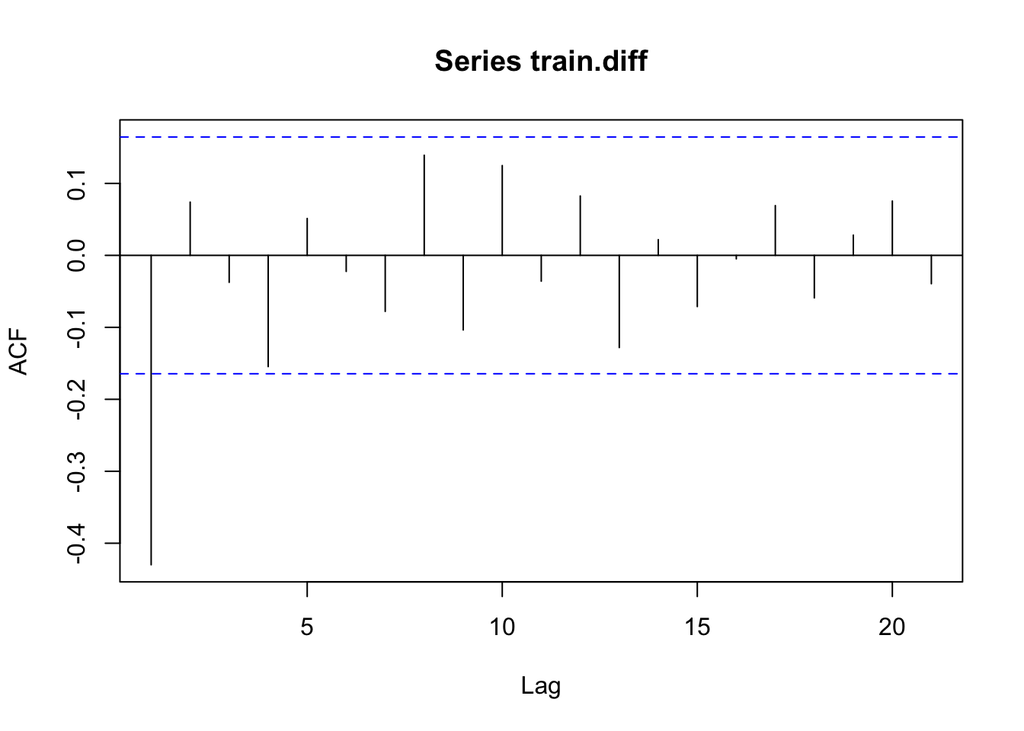

```r
acf(train.diff)
```

### Uji ADF

```r
tseries::adf.test(train.diff)
```

```
##
##  Augmented Dickey-Fuller Test
##
## data:  train.diff
## Dickey-Fuller = -7.3555, Lag order = 5, p-value = 0.01
## alternative hypothesis: stationary
```

$H_0$ : Data tidak stasioner dalam rataan

$H_1$ : Data stasioner dalam rataan

Berdasarkan uji ADF tersebut, didapat *p-value* sebesar 0.01 yang lebih kecil dari taraf nyata 5% dan menandakan bahwa data stasioner dalam rataan. Hal ini sesuai dengan hasil eksplorasi menggunakan plot time series dan plot ACF

## Identifikasi Model

### Plot ACF

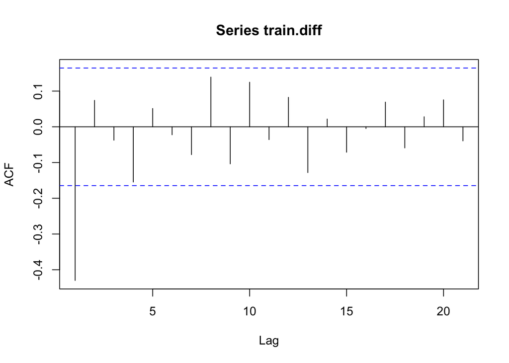

```r
acf (train.diff)
```

### Plot PACF

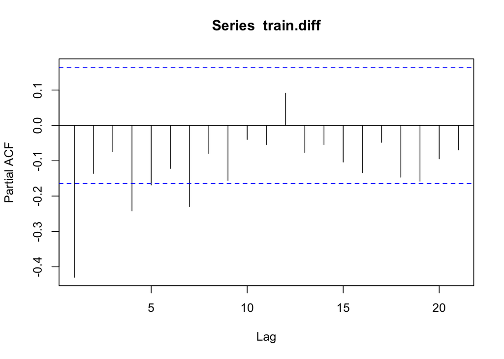

```r
pacf(train.diff)
```

### Plot EACF

```r
eacf(train.diff)
```

```
## AR/MA
##   0 1 2 3 4 5 6 7 8 9 10 11 12 13
## 0 x o o o o o o o o o o  o  o  o
## 1 x o o x o o o o o o o  o  o  o
## 2 x o x x o o o o o o o  o  o  o
## 3 x x x o o o o o o o o  o  o  o
## 4 x o x o o o o o o o o  o  o  o
## 5 x o x o o o o o o o o  o  o  o
## 6 x x x o o o o o o o o  o  o  o
## 7 x x o o o o o o o o o  o  o  o
```

Identifikasi model menggunakan plot EACF dilakukan dengan melihat ujung segitiga pada pola segitiga nol. Dalam hal ini model tentatif yang terbentuk adalah ARIMA(0,1,1)

## Pendugaan Parameter Model Tentatif

### ARIMA(0,1,1)

```r
model1.da=Arima(train.diff, order=c(0,1,1),method="ML")
summary(model1.da) #AIC=199.78
```

```
## Series: train.diff
## ARIMA(0,1,1)
##
## Coefficients:
##           ma1
##       -1.0000
## s.e.   0.0176
##
## sigma^2 = 0.2282:  log likelihood = -97.89
## AIC=199.78   AICc=199.87   BIC=205.68
##
## Training set error measures:
##                      ME      RMSE       MAE MPE MAPE      MASE       ACF1
## Training set 0.02454542 0.4743575 0.3520047 NaN  Inf 0.5959734 -0.3861468
```

```r
lmtest::coeftest(model1.da)
```

```
##
## z test of coefficients:
##
##      Estimate Std. Error z value  Pr(>|z|)
## ma1 -1.000000   0.017611 -56.782 < 2.2e-16 ***
## ---
## Signif. codes:  0 '***' 0.001 '**' 0.01 '*' 0.05 '.' 0.1 ' ' 1
```

Berdasarkan pendugaan parameter di atas, model yang dipilih adalah model ARIMA(0,1,1).

## Analisis Sisaan

### Eksplorasi Sisaan

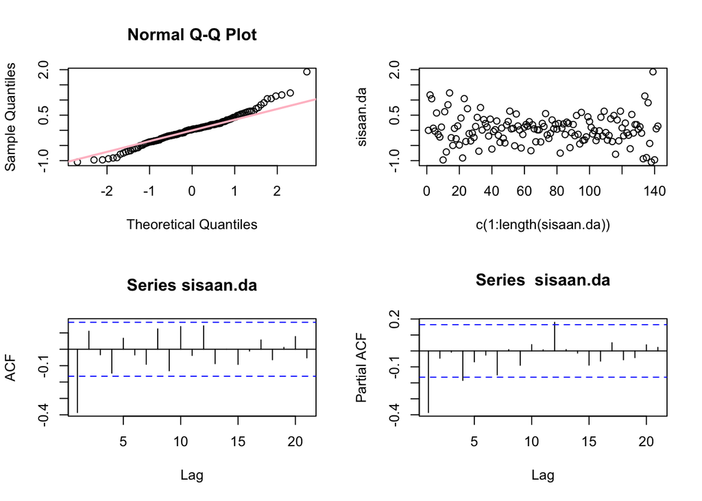

```r
sisaan.da <- model1.da$residuals
par(mfrow=c(2,2))
qqnorm(sisaan.da)
qqline(sisaan.da, col = "pink", lwd = 2)
plot(c(1:length(sisaan.da)),sisaan.da)
acf(sisaan.da)
pacf(sisaan.da)
```

### Uji Formal #### Sisaan menyebar normal

```r
ks.test(sisaan.da,"pnorm")
```

```
##
##  Asymptotic one-sample Kolmogorov-Smirnov test
##
## data:  sisaan.da
## D = 0.19988, p-value = 2.362e-05
## alternative hypothesis: two-sided
```

karena p-value < 0.05 maka sisaan tidak menyebar normal.

#### Sisaan saling bebas

```r
Box.test(sisaan.da, type = "Ljung")
```

```
##
##  Box-Ljung test
##
## data:  sisaan.da
## X-squared = 21.624, df = 1, p-value = 3.317e-06
```

karena p-value < 0.05 maka sisaan tidaK saling bebas.

#### Sisaan Homogen

```r
Box.test((sisaan.da)^2, type = "Ljung")
```

```
##
##  Box-Ljung test
##
## data:  (sisaan.da)^2
## X-squared = 21.465, df = 1, p-value = 3.603e-06
```

karena p-value < 0.05 maka sisaan tidak homogen.

#### Nilai harapan sisaan sama dengan nol

```r
t.test(sisaan.da, mu = 0, conf.level = 0.95)
```

```
##
##  One Sample t-test
##
## data:  sisaan.da
## t = 0.61526, df = 141, p-value = 0.5394
## alternative hypothesis: true mean is not equal to 0
## 95 percent confidence interval:
##  -0.05432345  0.10341429
## sample estimates:
##  mean of x
## 0.02454542
```

karena p-value > 0.05 maka nilai harapan sisaan sama dengan nol.

## Peramalan

Peramalan dilakukan menggunakan fungsi forecast() . Contoh peramalan berikut ini dilakukan untuk 11 hari ke depan.

```r
ramalan.da <- forecast::forecast(model1.da, h = 11)
ramalan.da
```

```
##     Point Forecast      Lo 80     Hi 80      Lo 95     Hi 95
## 143     0.01161972 -0.6027726 0.6260121 -0.9280123 0.9512517
## 144     0.01161972 -0.6027726 0.6260121 -0.9280123 0.9512517
## 145     0.01161972 -0.6027726 0.6260121 -0.9280123 0.9512517
## 146     0.01161972 -0.6027726 0.6260121 -0.9280123 0.9512517
## 147     0.01161972 -0.6027726 0.6260121 -0.9280123 0.9512517
## 148     0.01161972 -0.6027726 0.6260121 -0.9280123 0.9512517
## 149     0.01161972 -0.6027726 0.6260121 -0.9280123 0.9512517
## 150     0.01161972 -0.6027726 0.6260121 -0.9280123 0.9512517
## 151     0.01161972 -0.6027726 0.6260121 -0.9280123 0.9512517
## 152     0.01161972 -0.6027726 0.6260121 -0.9280123 0.9512517
## 153     0.01161972 -0.6027726 0.6260121 -0.9280123 0.9512517
```

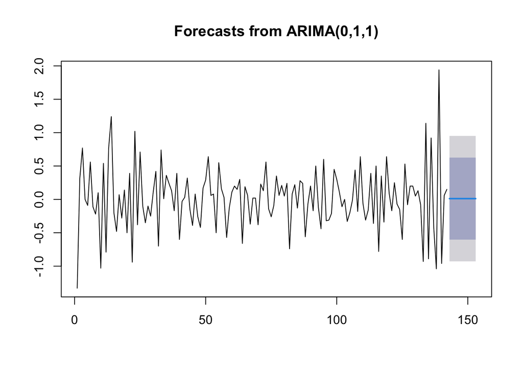

```r
data.ramalan.da <- ramalan.da$mean
plot(ramalan.da)
```

Berdasarkan hasil plot ramalan di atas, dapat dilihat bahwa ramalan ARIMA(0,1,1) cenderung stabil hingga akhir periode. Selanjutnya, dapat dicari nilai akurasi antara hasil ramalan dengan data uji sebagai berikut.

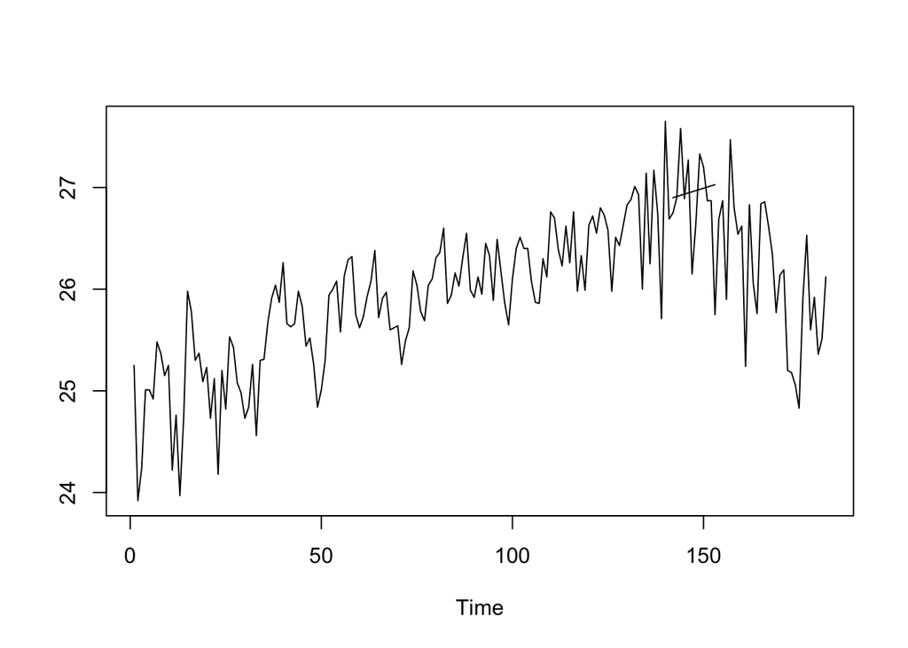

```r
data.train <- data67$T2M
data.train <- ts(data.train)
pt_1 <- data.train[143] #nilai akhir data latih
hasil.forc.Diff <- data.ramalan.da
hasil <- diffinv(hasil.forc.Diff, differences = 1) + pt_1
#has.1 sama hasilnta dengan: cumsum(c(pt_1,hasil.forc.Diff))
ts.plot(data.train, hasil)
```

```r
perbandingan.da<-matrix(data=c(head(data.test, n=11), hasil[-1]),
                     nrow = 11, ncol = 2)
colnames(perbandingan.da)<-c("Aktual","Hasil Forecast")
perbandingan.da
```

```
##       Aktual Hasil Forecast
##  [1,]  27.58       26.91162
##  [2,]  26.89       26.92324
##  [3,]  27.27       26.93486
##  [4,]  26.15       26.94648
##  [5,]  26.65       26.95810
##  [6,]  27.33       26.96972
##  [7,]  27.20       26.98134
##  [8,]  26.87       26.99296
##  [9,]  26.87       27.00458
## [10,]  25.75       27.01620
## [11,]  26.69       27.02782
```

```r
accuracy(ts(hasil[-1]), head(data.test, n=11))
```

```
##                  ME      RMSE       MAE        MPE     MAPE
## Test set -0.1288092 0.5408479 0.4165301 -0.5174885 1.567409
```